# Sampling from a Bivariate Normal Distribution

Nikolai German

2025-07-06

# 1 Introduction

We demonstrate how to transform a bivariate standard normal random variable $Z \sim \mathcal{N}_2(\boldsymbol{0}, I_2)$ into a general bivariate normal random variable $X \sim \mathcal{N}_2(\boldsymbol{\mu}, \Sigma)$ using the Cholesky decomposition.

## 1.1 Mathematical Foundation

The transformation is based on:
$$X =
\boldsymbol{\mu} + R^{\top}Z$$
where $R$ is the Cholesky factor of the covariance matrix $\Sigma = R^{\top} R$.

# 2 Generating Standard Bivariate Normal Samples

First we construct $Z$ by sampling two independent standard normal variables:

```r
set.seed(42)
Z <- cbind(Z_1 = rnorm(100),
            Z_2 = rnorm(100))
```

## 2.1 Verifying Standard Properties

We check that our samples have the expected properties of standard bivariate normal variables:

```r
# means
round(colMeans(Z), 2)
```

```
##   Z_1   Z_2
##  0.03 -0.09
```

```r
# variance
round(apply(Z, MARGIN = 2, var), 2)
```

```
##  Z_1  Z_2
## 1.08 0.82
```

```r
# covariance
round(cov(Z[,1], Z[,2]), 2)
```

```
## [1] 0.03
```

The results confirm approximately zero means, unit variances, and zero covariance.

# 3 Setting Target Parameters

Next, we define the desired mean vector $\boldsymbol{\mu}$ and covariance matrix $\Sigma$:

```r
Sigma <- matrix(c(5, 2, 2, 1), ncol = 2)
mu <- c(-1, 1)
```

# 4 Cholesky Decomposition

We compute the Cholesky factor. Note that R’s `chol()` function returns an upper triangular matrix:

```r
(R <- chol(Sigma))
```

```
##          [,1]      [,2]
## [1,] 2.236068 0.8944272
## [2,] 0.000000 0.4472136
```

This gives us $\Sigma = R^{\top} R$ where $R$ is upper triangular.

# 5 Transformation

We apply the transformation $X = \boldsymbol{\mu} + R^{\top} Z$:

```r
X <- t(mu + t(Z %*% R))
colnames(X) <- c("X_1", "X_2")
```

## 5.1 Verifying Transformed Properties

We check that the transformed samples have the desired properties:

```r
round(colMeans(X), 2)
```

```
##   X_1   X_2
## -0.93  0.99
```

```r
round(apply(X, MARGIN = 2, var), 2)
```

```
##  X_1  X_2
## 5.42 1.05
```

```r
round(cov(X[,1], X[,2]), 2)
```

```
## [1] 2.2
```

The results show that our transformation successfully produces samples with the target mean vector and covariance structure.

# 6 Visualization

Finally, we visualize both the original standard bivariate normal samples and the transformed samples:

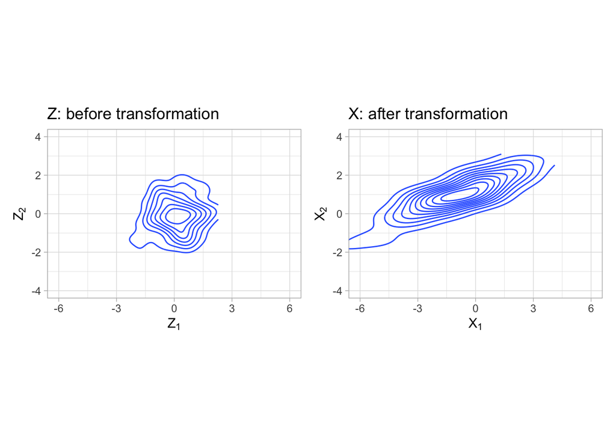

```r
library(ggplot2)
library(patchwork)

p_01 <- ggplot() +
  geom_density2d(data = as.data.frame(Z), aes(Z_1, Z_2)) +
  coord_fixed(ratio = 1, xlim = c(-6,6), ylim = c(-4,4)) +
  labs(x = latex2exp::TeX("$Z_1$"),
       y = latex2exp::TeX("$Z_2$"),
       title = "Z: before transformation") +
  theme_light()

p_02 <- ggplot() +
  geom_density_2d(data = as.data.frame(X), aes(X_1, X_2)) +
  coord_fixed(ratio = 1, xlim = c(-6,6), ylim = c(-4,4)) +
  labs(x = latex2exp::TeX("$X_1$"),
       y = latex2exp::TeX("$X_2$"),
       title = "X: after transformation") +
  theme_light()

(p <- (p_01 | p_02))
```

The visualization clearly shows how the Cholesky transformation changes both the location (mean) and the shape/orientation (covariance structure) of the bivariate normal distribution.